# a4a preliminary runs

# 1st trial

## a4a submodel setup

### fishing mortality at age

$$F \sim s(year, k =20) + s(age, k = 5)$$

### recruitment model

$$SR \sim factor(age)$$

### variance

Assummed constant for the indices and effect on a age $\sim s(age, k = 3)$ for catch observations.

## Results

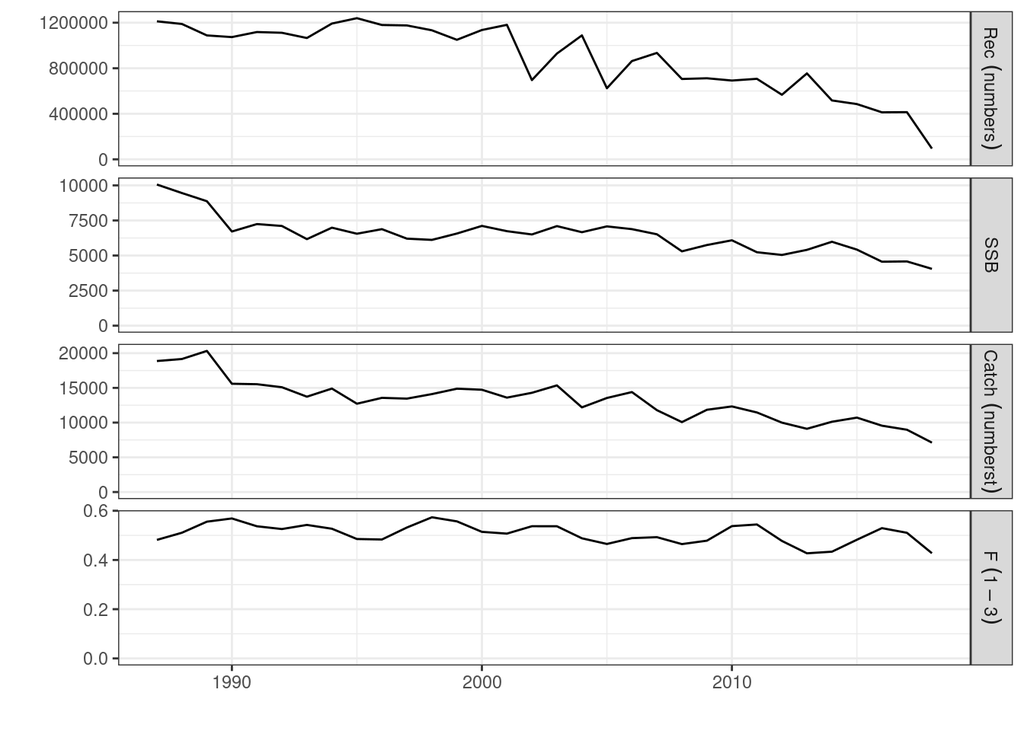

**Figure 3**. Assessment Results.

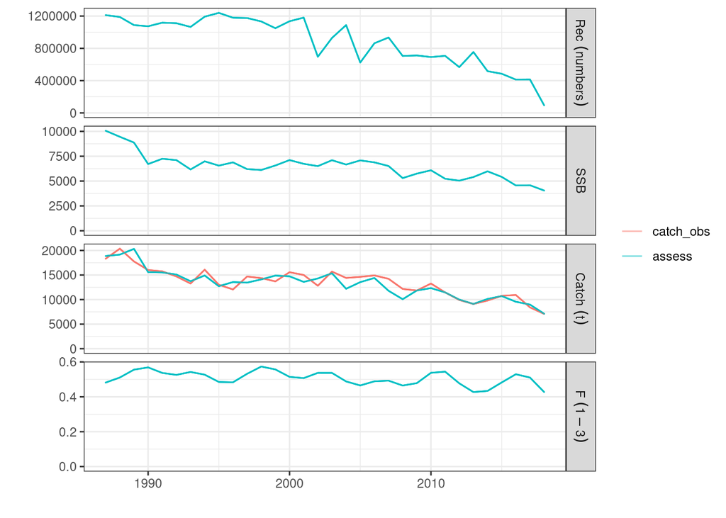

**Figure 4**. Assessment Results against observed catch.

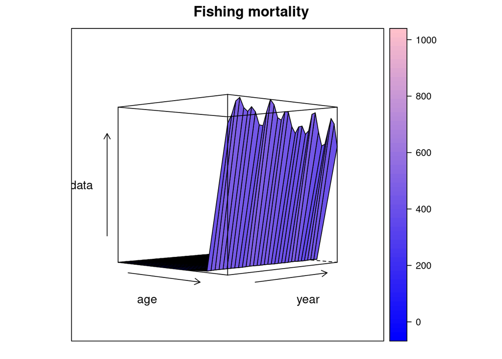

**Figure 5**. Fishing mortality 3D plot.

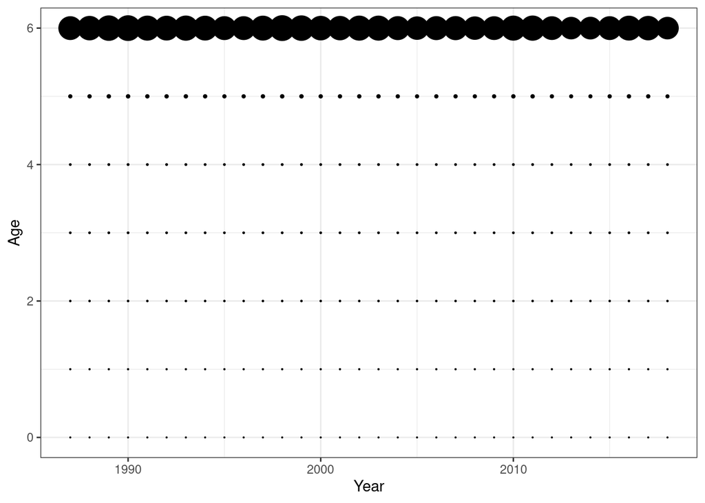

**Figure 6**. Fishing mortality bubble plot.

## Diagnostics

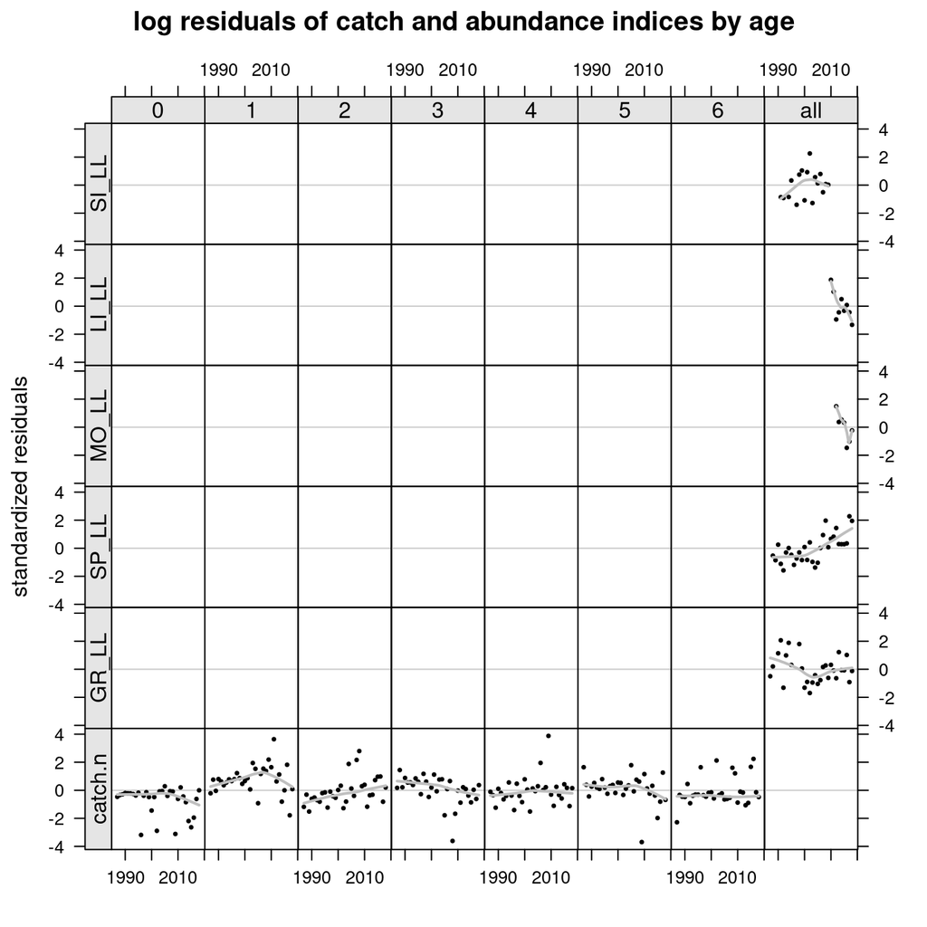

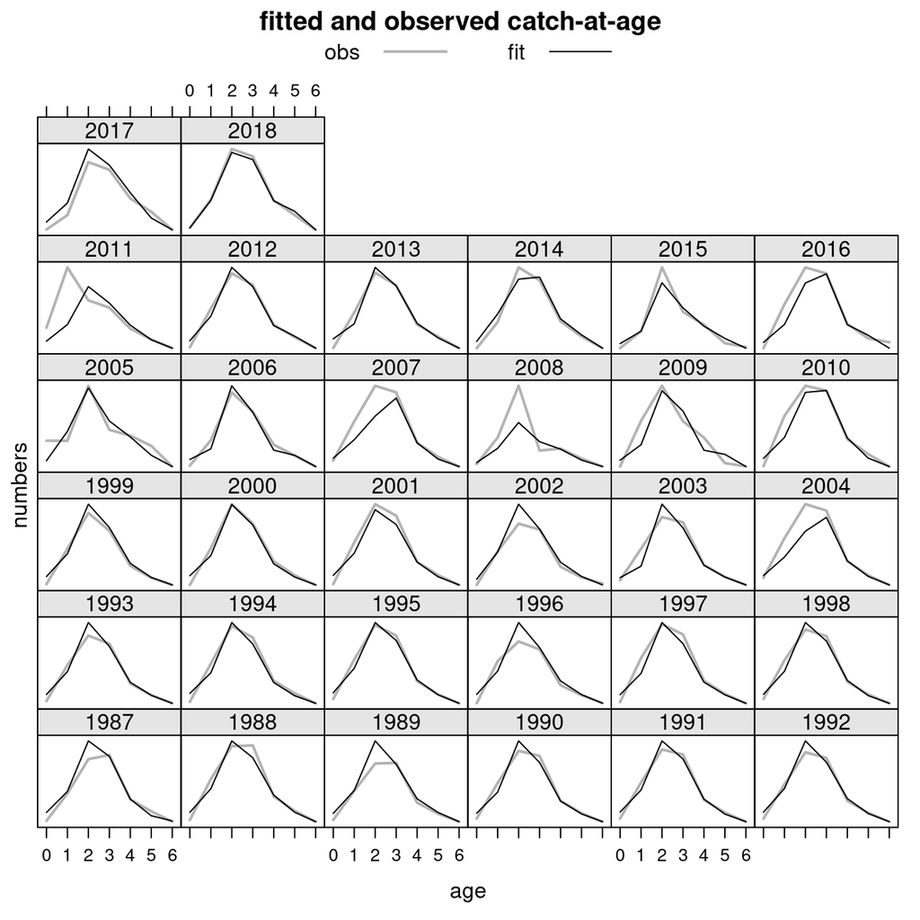

# 2nd trial

## a4a submodel setup

```r
idx_bio2 = FLIndices(idx_bio[1],idx_bio[2],idx_bio[3],idx_bio[4])
```

### fishing mortality at age

$$F \sim s(year, k = 15) + s(age, k = 5)$$

### recruitment model

$$SR \sim factor(age)$$

### variance

Assummed constant for the indices and effect on a age $\sim s(age, k = 3)$ for catch observations.

## Results

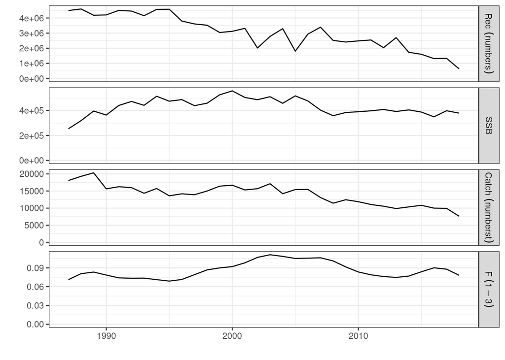

**Figure 8**. Assessment Results 2nd run.

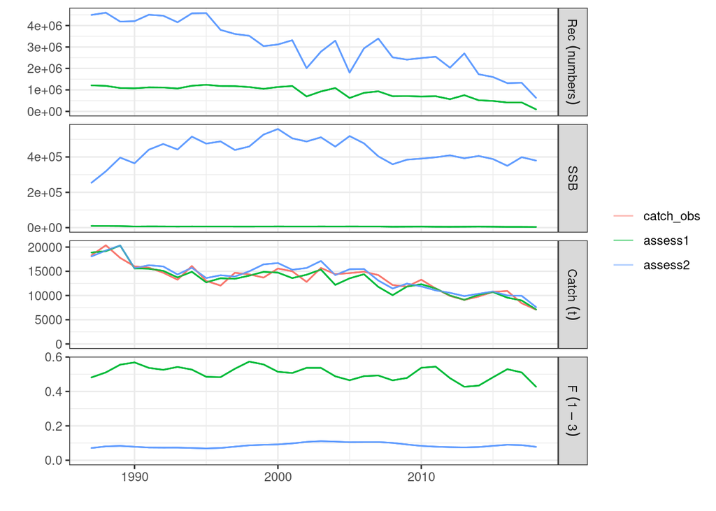

**Figure 9**. Assessment Results against observed catch and 1st run.

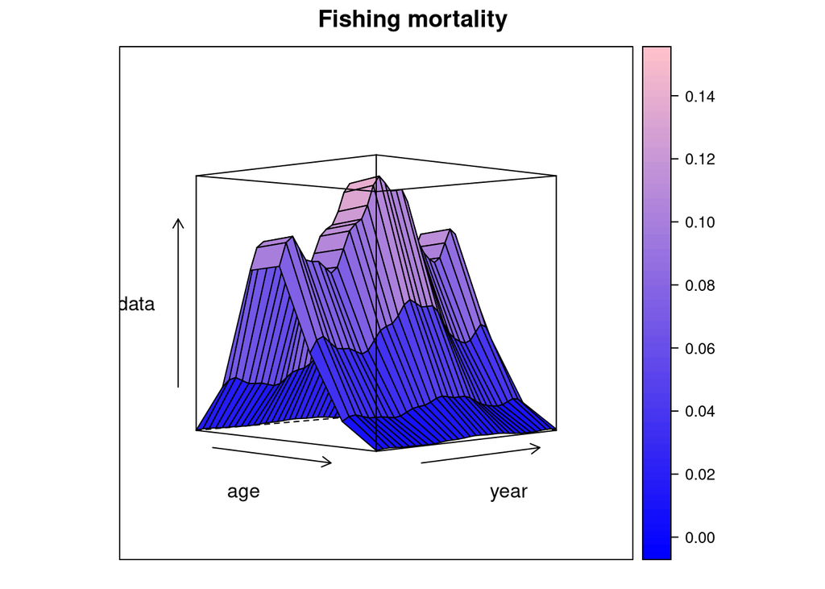

**Figure 10**. Fishing mortality 3D plot.

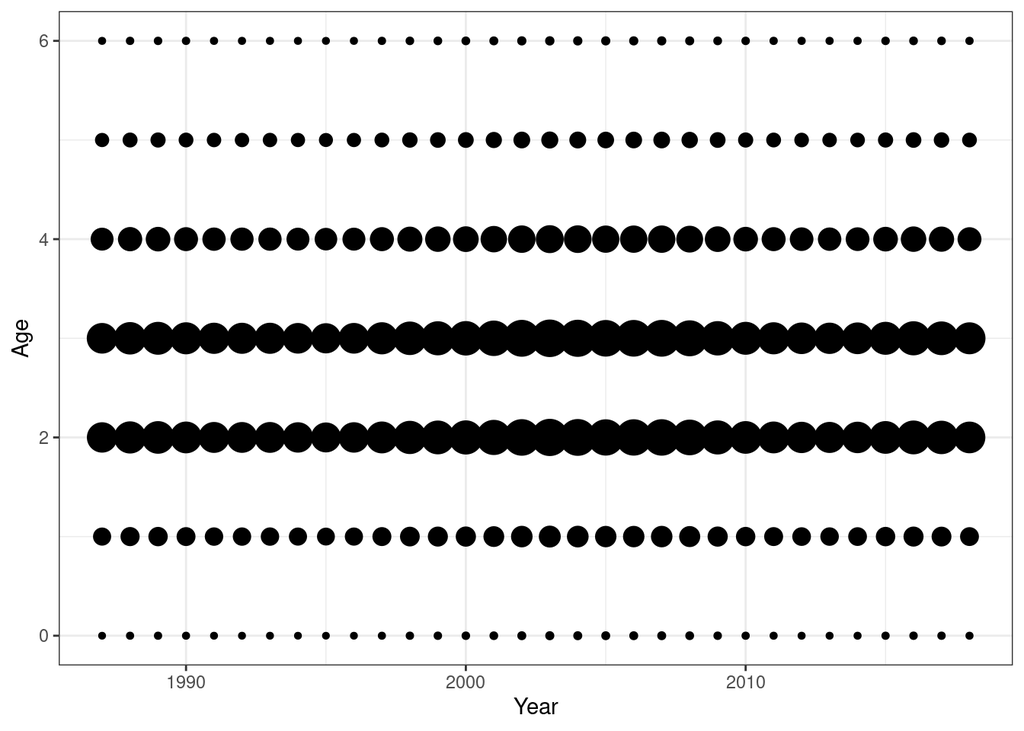

**Figure 11**. Fishing mortality bubble plot.